# R Notebook

Análisis de correlaciones Vamos a ver un ejemplo rápido de las funciones que se usan para el análisis de correlaciones y cómo se analizan.

Cargamos el dataset de coches y observamos la correlación de consumo “mpg” respecto a las primeras variables, en corr tenemos el coeficiente de correlación R:

```r
data(mtcars)
mtcars
```

|  | mpg | cyl | disp | hp | drat | wt | qsec | vs | am | gear | carb |
| --- | --- | --- | --- | --- | --- | --- | --- | --- | --- | --- | --- |
| Mazda RX4 | 21.0 | 6 | 160.0 | 110 | 3.90 | 2.620 | 16.46 | 0 | 1 | 4 | 4 |
| Mazda RX4 Wag | 21.0 | 6 | 160.0 | 110 | 3.90 | 2.875 | 17.02 | 0 | 1 | 4 | 4 |
| Datsun 710 | 22.8 | 4 | 108.0 | 93 | 3.85 | 2.320 | 18.61 | 1 | 1 | 4 | 1 |
| Hornet 4 Drive | 21.4 | 6 | 258.0 | 110 | 3.08 | 3.215 | 19.44 | 1 | 0 | 3 | 1 |
| Hornet Sportabout | 18.7 | 8 | 360.0 | 175 | 3.15 | 3.440 | 17.02 | 0 | 0 | 3 | 2 |
| Valiant | 18.1 | 6 | 225.0 | 105 | 2.76 | 3.460 | 20.22 | 1 | 0 | 3 | 1 |
| Duster 360 | 14.3 | 8 | 360.0 | 245 | 3.21 | 3.570 | 15.84 | 0 | 0 | 3 | 4 |
| Merc 240D | 24.4 | 4 | 146.7 | 62 | 3.69 | 3.190 | 20.00 | 1 | 0 | 4 | 2 |
| Merc 230 | 22.8 | 4 | 140.8 | 95 | 3.92 | 3.150 | 22.90 | 1 | 0 | 4 | 2 |
| Merc 280 | 19.2 | 6 | 167.6 | 123 | 3.92 | 3.440 | 18.30 | 1 | 0 | 4 | 4 |

[output cut: 22 more lines]

```r
#install.packages("GGally")  #Es una extensión de ggplot2
install.packages("Hmisc")
```

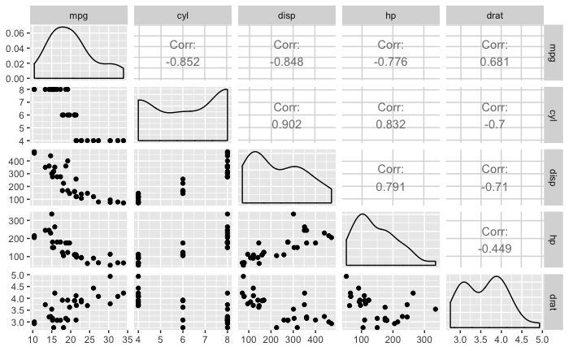

```r
#library(GGally)
options(warn=0)
ggpairs(mtcars[,1:5])
```

Vemos que muchas de las variables están correladas.

```r
library(Hmisc)
```

```r
corrs<-rcorr(as.matrix(mtcars))   #devuelve los coeficinetes de correlación y el pvalor del test de pearson
corrs$r
```

```
            mpg        cyl       disp         hp        drat         wt        qsec         vs          am       gear        carb
mpg   1.0000000 -0.8521620 -0.8475514 -0.7761684  0.68117191 -0.8676594  0.41868403  0.6640389  0.59983243  0.4802848 -0.55092507
cyl  -0.8521620  1.0000000  0.9020329  0.8324475 -0.69993811  0.7824958 -0.59124207 -0.8108118 -0.52260705 -0.4926866  0.52698829
disp -0.8475514  0.9020329  1.0000000  0.7909486 -0.71021393  0.8879799 -0.43369788 -0.7104159 -0.59122704 -0.5555692  0.39497686
hp   -0.7761684  0.8324475  0.7909486  1.0000000 -0.44875912  0.6587479 -0.70822339 -0.7230967 -0.24320426 -0.1257043  0.74981247
drat  0.6811719 -0.6999381 -0.7102139 -0.4487591  1.00000000 -0.7124406  0.09120476  0.4402785  0.71271113  0.6996101 -0.09078980
wt   -0.8676594  0.7824958  0.8879799  0.6587479 -0.71244065  1.0000000 -0.17471588 -0.5549157 -0.69249526 -0.5832870  0.42760594
qsec  0.4186840 -0.5912421 -0.4336979 -0.7082234  0.09120476 -0.1747159  1.00000000  0.7445354 -0.22986086 -0.2126822 -0.65624923
vs    0.6640389 -0.8108118 -0.7104159 -0.7230967  0.44027846 -0.5549157  0.74453544  1.0000000  0.16834512  0.2060233 -0.56960714
am    0.5998324 -0.5226070 -0.5912270 -0.2432043  0.71271113 -0.6924953 -0.22986086  0.1683451  1.00000000  0.7940588  0.05753435
gear  0.4802848 -0.4926866 -0.5555692 -0.1257043  0.69961013 -0.5832870 -0.21268223  0.2060233  0.79405876  1.0000000  0.27407284
carb -0.5509251  0.5269883  0.3949769  0.7498125 -0.09078980  0.4276059 -0.65624923 -0.5696071  0.05753435  0.2740728  1.00000000
```

```r
corrs$P
```

```
              mpg          cyl         disp           hp         drat           wt         qsec           vs           am         gear         carb
mpg            NA 6.112688e-10 9.380328e-10 1.787835e-07 1.776240e-05 1.293958e-10 1.708199e-02 3.415937e-05 2.850207e-04 5.400948e-03 1.084446e-03
cyl  6.112688e-10           NA 1.803002e-12 3.477861e-09 8.244636e-06 1.217567e-07 3.660533e-04 1.843018e-08 2.151207e-03 4.173297e-03 1.942340e-03
disp 9.380328e-10 1.803002e-12           NA 7.142679e-08 5.282022e-06 1.222311e-11 1.314404e-02 5.235012e-06 3.662114e-04 9.635921e-04 2.526789e-02
hp   1.787835e-07 3.477861e-09 7.142679e-08           NA 9.988772e-03 4.145827e-05 5.766253e-06 2.940896e-06 1.798309e-01 4.930119e-01 7.827810e-07
drat 1.776240e-05 8.244636e-06 5.282022e-06 9.988772e-03           NA 4.784260e-06 6.195826e-01 1.167553e-02 4.726790e-06 8.360110e-06 6.211834e-01
wt   1.293958e-10 1.217567e-07 1.222311e-11 4.145827e-05 4.784260e-06           NA 3.388683e-01 9.798492e-04 1.125440e-05 4.586601e-04 1.463861e-02
qsec 1.708199e-02 3.660533e-04 1.314404e-02 5.766253e-06 6.195826e-01 3.388683e-01           NA 1.029669e-06 2.056621e-01 2.425344e-01 4.536949e-05
vs   3.415937e-05 1.843018e-08 5.235012e-06 2.940896e-06 1.167553e-02 9.798492e-04 1.029669e-06           NA 3.570439e-01 2.579439e-01 6.670496e-04
am   2.850207e-04 2.151207e-03 3.662114e-04 1.798309e-01 4.726790e-06 1.125440e-05 2.056621e-01 3.570439e-01           NA 5.834043e-08 7.544526e-01
gear 5.400948e-03 4.173297e-03 9.635921e-04 4.930119e-01 8.360110e-06 4.586601e-04 2.425344e-01 2.579439e-01 5.834043e-08           NA 1.290291e-01
carb 1.084446e-03 1.942340e-03 2.526789e-02 7.827810e-07 6.211834e-01 1.463861e-02 4.536949e-05 6.670496e-04 7.544526e-01 1.290291e-01           NA
```

Si queremos estudiar en concreto “mpg” respecto al resto:

```r
R<- corrs$r
R[1,]
```

```
       mpg        cyl       disp         hp       drat         wt       qsec         vs         am       gear       carb
 1.0000000 -0.8521620 -0.8475514 -0.7761684  0.6811719 -0.8676594  0.4186840  0.6640389  0.5998324  0.4802848 -0.5509251
```

```r
P<- corrs$P
P[1,]
```

```
         mpg          cyl         disp           hp         drat           wt         qsec           vs           am         gear         carb
          NA 6.112688e-10 9.380328e-10 1.787835e-07 1.776240e-05 1.293958e-10 1.708199e-02 3.415937e-05 2.850207e-04 5.400948e-03 1.084446e-03
```

¿Cómo interpretamos estos resultados? https://support.minitab.com/es-mx/minitab/18/help-and-how-to/statistics/basic-statistics/how-to/correlation/interpret-the-results/key-results/

-Nunca se debe concluir que los cambios en una variable causan cambios en otra basándose solamente en la correlación. Solo los experimentos controlados adecuadamente permiten determinar si una relación es causal. -El coeficiente de correlación de Pearson es muy sensible a valores de datos extremos. Un solo valor que sea muy diferente de los otros valores en un conjunto de datos puede cambiar considerablemente el valor del coeficiente. Usted debe tratar de identificar la causa de cualquier valor extremo. Corrija cualquier error de entrada de datos o de medición. Considere eliminar los valores de datos que estén asociados con eventos anormales y únicos (causas especiales). Luego, repita el análisis. -Un coeficiente de correlación de Pearson bajo no significa que no exista relación entre las variables. Las variables pueden tener una relación no lineal. Para verificar gráficamente relaciones no lineales, cree una Gráfica de dispersión o utilice Gráfica de línea ajustada.

Para determinar si la correlación entre las variables es significativa, compare el valor p con su nivel de significancia. Por lo general, un nivel de significancia (denotado como α o alfa) de 0.05 funciona adecuadamente. Un α de 0.05 indica que el riesgo de concluir que existe una correlación, cuando en realidad no es así, es 5%. El valor p indica si el coeficiente de correlación es significativamente diferente de 0. (Un coeficiente de 0 indica que no existe una relación lineal).

Valor p ≤ α: La correlación es estadísticamente significativa Si el valor p es menor que o igual al nivel de significancia, entonces usted puede concluir que la correlación es diferente de 0. Valor p > α: La correlación no es estadísticamente significativa Si el valor p es mayor que el nivel de significancia, entonces usted no puede concluir que la correlación es diferente de 0.

Por tanto, podemos decir por ejemplo, que la correlación entre mpg y cyl es significativa.

```r
cor(mtcars$mpg, mtcars)
```

```
     mpg       cyl       disp         hp      drat         wt     qsec        vs        am      gear       carb
[1,]   1 -0.852162 -0.8475514 -0.7761684 0.6811719 -0.8676594 0.418684 0.6640389 0.5998324 0.4802848 -0.5509251
```

Coeficiente de determinación lineal R^2: toma valores entre 0 y 1. Representa la proporción de la variabilidad de la variable Y, que queda explicada por la variable X. Si vamos a construir modelos lineales, estamos interesados en que los predictores usados tengan el mayor R^2 con la variable objetivo Y.

Se calcula simplemente elevando al cuadrado la correlación.

Siguendo con el ejemplo de mpg

```r
cor(mtcars$mpg, mtcars)^2
```

```
     mpg     cyl      disp        hp      drat        wt      qsec        vs        am      gear      carb
[1,]   1 0.72618 0.7183433 0.6024373 0.4639952 0.7528328 0.1752963 0.4409477 0.3597989 0.2306734 0.3035184
```

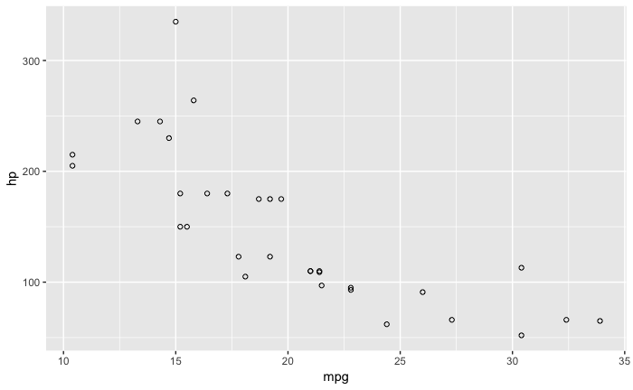

```r
library(ggplot2)
ggplot(mtcars,aes(x=mpg,y=hp)) +
  geom_point(shape=1)
```

```r
cor(mtcars$mpg, mtcars$hp)
```

```
[1] -0.7761684
```

```r
cor(mtcars$mpg, log(mtcars$hp))
```

```
[1] -0.8487707
```

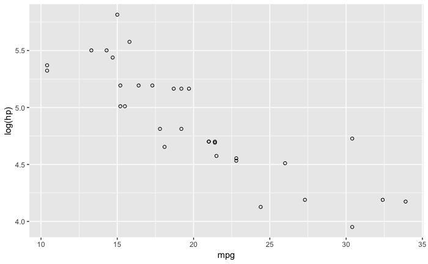

```r
ggplot(mtcars,aes(x=mpg,y=log(hp))) +
  geom_point(shape=1)
```

```r
cor(mtcars$mpg, exp(mtcars$hp))
```

```
[1] -0.1541299
```

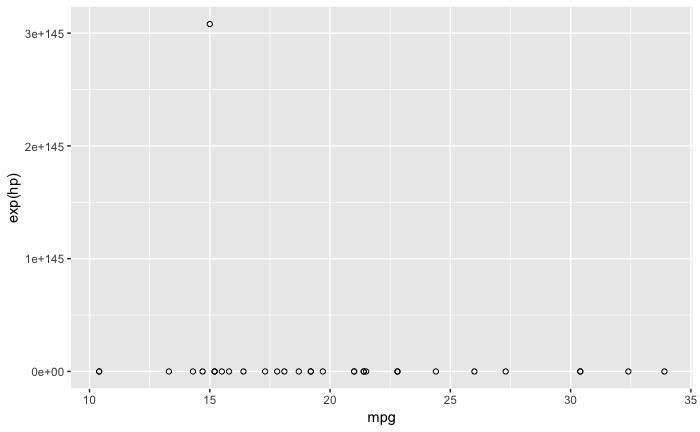

```r
ggplot(mtcars,aes(x=mpg,y=exp(hp))) +
  geom_point(shape=1)
```

```r
cor(mtcars$mpg, sqrt(mtcars$hp))
```

```
[1] -0.8193547
```

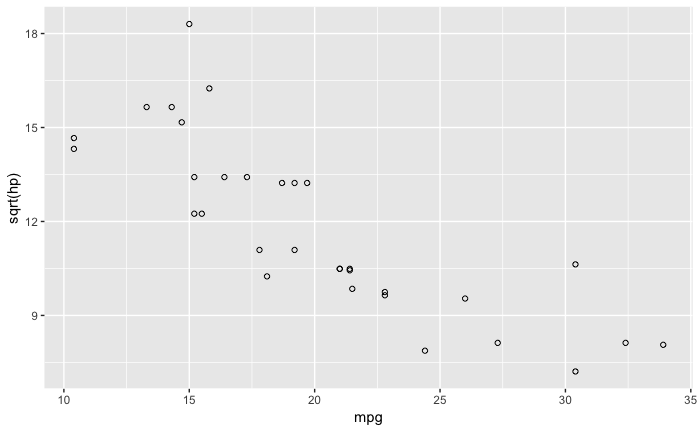

```r
ggplot(mtcars,aes(x=mpg,y=sqrt(hp))) +
  geom_point(shape=1)
```